# Stat 490 HW2

Janine Yanes

```r
#Load packages
library(knitr)
library(kableExtra)
library(tidyverse)
```

## Problem 1

```r
table_1 = data.frame(
  Unit = c(1:10),
  Treatment.0 = c(10.04, 9.63, 7.26, 8.80, 10.59, 10.78, 7.58, 9.27, 6.75, 9.49),
  Treatment.1 = c(14.20, 13.51, 11.52, 13.97, 13.48, 12.18, 10.09, 11.61, 13.85, 12.97)
)
table_2 = data.frame(
  Unit = c(1:10),
  Treatment.0 = c(2.77, 2.26, 0.69, 1.49, 3.65, 4.01, 0.81, 1.89, 0.53, 2.10),
  Treatment.1 = c(4.77, 4.26, 2.69, 3.49, 5.65, 6.01, 2.81, 3.89, 2.53, 4.10)
)
table_3 = data.frame(
  Unit = c(1:10),
  Treatment.0 = c(2.77, 2.26, 0.69, 1.49, 3.65, 4.01, 0.81, 1.89, 0.53, 2.10),
  Treatment.1 = c(8.18, 5.79, 2.14, 7.30, 5.71, 2.97, 1.05, 2.24, 6.86, 4.41)
)

cat(c('<table style="width:100%"><tr valign="top"><td>',
  table_1 %>%
    kable("html", align = 'clc', caption = 'Table 1') %>%
      column_spec(1, bold = T, border_right = T) %>%
      kable_styling(full_width = F),
  '</td><td>',
  table_2 %>%
    kable("html", align = 'clc', caption = 'Table 2') %>%
      column_spec(1, bold = T, border_right = T) %>%
      kable_styling(full_width = F) ,
  '</td><td>',
  table_3 %>%
    kable("html", align = 'clc', caption = 'Table 3') %>%
      column_spec(1, bold = T, border_right = T) %>%
      kable_styling(full_width = F), '</td><tr></table>'),
  sep = '')
```

Table 1

| Unit | Treatment.0 | Treatment.1 |
| --- | --- | --- |
| 1 | 10.04 | 14.20 |
| 2 | 9.63 | 13.51 |
| 3 | 7.26 | 11.52 |
| 4 | 8.80 | 13.97 |
| 5 | 10.59 | 13.48 |
| 6 | 10.78 | 12.18 |
| 7 | 7.58 | 10.09 |
| 8 | 9.27 | 11.61 |
| 9 | 6.75 | 13.85 |
| 10 | 9.49 | 12.97 |

Table 2

| Unit | Treatment.0 | Treatment.1 |
| --- | --- | --- |
| 1 | 2.77 | 4.77 |
| 2 | 2.26 | 4.26 |
| 3 | 0.69 | 2.69 |
| 4 | 1.49 | 3.49 |
| 5 | 3.65 | 5.65 |
| 6 | 4.01 | 6.01 |
| 7 | 0.81 | 2.81 |
| 8 | 1.89 | 3.89 |
| 9 | 0.53 | 2.53 |
| 10 | 2.10 | 4.10 |

Table 3

| Unit | Treatment.0 | Treatment.1 |
| --- | --- | --- |
| 1 | 2.77 | 8.18 |
| 2 | 2.26 | 5.79 |
| 3 | 0.69 | 2.14 |
| 4 | 1.49 | 7.30 |
| 5 | 3.65 | 5.71 |
| 6 | 4.01 | 2.97 |
| 7 | 0.81 | 1.05 |
| 8 | 1.89 | 2.24 |
| 9 | 0.53 | 6.86 |
| 10 | 2.10 | 4.41 |

### i.

```r
#Table 1
t1_tr0_avg = mean(table_1$Treatment.0)
t1_tr1_avg = mean(table_1$Treatment.1)
t1_tr0_med = median(table_1$Treatment.0)
t1_tr1_med = median(table_1$Treatment.1)
t1_tr0_var = var(table_1$Treatment.0)
t1_tr1_var = var(table_1$Treatment.1)
t1_tr0_ran = max(table_1$Treatment.0) - min(table_1$Treatment.0)
t1_tr1_ran = max(table_1$Treatment.1) - min(table_1$Treatment.1)

#Table 2
t2_tr0_avg = mean(table_2$Treatment.0)
t2_tr1_avg = mean(table_2$Treatment.1)
t2_tr0_med = median(table_2$Treatment.0)
t2_tr1_med = median(table_2$Treatment.1)
t2_tr0_var = var(table_2$Treatment.0)
t2_tr1_var = var(table_2$Treatment.1)
t2_tr0_ran = max(table_2$Treatment.0) - min(table_2$Treatment.0)
t2_tr1_ran = max(table_2$Treatment.1) - min(table_2$Treatment.1)

#Table 3
t3_tr0_avg = mean(table_3$Treatment.0)
t3_tr1_avg = mean(table_3$Treatment.1)
t3_tr0_med = median(table_3$Treatment.0)
t3_tr1_med = median(table_3$Treatment.1)
t3_tr0_var = var(table_3$Treatment.0)
t3_tr1_var = var(table_3$Treatment.1)
t3_tr0_ran = max(table_3$Treatment.0) - min(table_3$Treatment.0)
t3_tr1_ran = max(table_3$Treatment.1) - min(table_3$Treatment.1)

table_1i = data.frame(
  Unit = c("Avg", "Med", "Var", "Ran"),
  Treatment.0 = c(t1_tr0_avg, t1_tr0_med, t1_tr0_var, t1_tr0_ran),
  Treatment.1 = c(t1_tr1_avg, t1_tr1_med, t1_tr1_var, t1_tr1_ran)
)
table_2i = data.frame(
  Unit = c("Avg", "Med", "Var", "Ran"),
  Treatment.0 = c(t2_tr0_avg, t2_tr0_med, t2_tr0_var, t2_tr0_ran),
  Treatment.1 = c(t2_tr1_avg, t2_tr1_med, t2_tr1_var, t2_tr1_ran)
)
table_3i = data.frame(
  Unit = c("Avg", "Med", "Var", "Ran"),
  Treatment.0 = c(t3_tr0_avg, t3_tr0_med, t3_tr0_var, t3_tr0_ran),
  Treatment.1 = c(t3_tr1_avg, t3_tr1_med, t3_tr1_var, t3_tr1_ran)
)

cat(c('<table style="width:100%"><tr valign="top"><td>',
  table_1i %>%
    kable("html", align = 'clc', caption = 'Table 1 summaries') %>%
      column_spec(1, bold = T, border_right = T) %>%
      kable_styling(full_width = F),
  '</td><td>',
  table_2i %>%
    kable("html", align = 'clc', caption = 'Table 2 summaries') %>%
      column_spec(1, bold = T, border_right = T) %>%
      kable_styling(full_width = F) ,
  '</td><td>',
  table_3i %>%
    kable("html", align = 'clc', caption = 'Table 3 summaries') %>%
      column_spec(1, bold = T, border_right = T) %>%
      kable_styling(full_width = F), '</td><tr></table>'),
  sep = '')
```

Table 1 summaries

| Unit | Treatment.0 | Treatment.1 |
| --- | --- | --- |
| Avg | 9.019000 | 12.738000 |
| Med | 9.380000 | 13.225000 |
| Var | 1.958988 | 1.796818 |
| Ran | 4.030000 | 4.110000 |

Table 2 summaries

| Unit | Treatment.0 | Treatment.1 |
| --- | --- | --- |
| Avg | 2.020000 | 4.020000 |
| Med | 1.995000 | 3.995000 |
| Var | 1.443822 | 1.443822 |
| Ran | 3.480000 | 3.480000 |

Table 3 summaries

| Unit | Treatment.0 | Treatment.1 |
| --- | --- | --- |
| Avg | 2.020000 | 4.66500 |
| Med | 1.995000 | 5.06000 |
| Var | 1.443822 | 6.08185 |
| Ran | 3.480000 | 7.13000 |

### ii.

```r
t1_tau = table_1$Treatment.1 - table_1$Treatment.0
t2_tau = table_2$Treatment.1 - table_2$Treatment.0
t3_tau = table_3$Treatment.1 - table_3$Treatment.0

table_1ii = data.frame(
  Unit = c(1:10),
  τ = t1_tau
)
table_2ii = data.frame(
  Unit = c(1:10),
  τ = t2_tau
)
table_3ii = data.frame(
  Unit = c(1:10),
  τ = t3_tau
)

cat(c('<table style="width:50%"><tr valign="top"><td>',
  table_1ii %>%
    kable("html", align = 'clc', caption = 'Table 1 tau') %>%
      column_spec(1, bold = T, border_right = T) %>%
      kable_styling(full_width = F),
  '</td><td>',
  table_2ii %>%
    kable("html", align = 'clc', caption = 'Table 2 tau') %>%
      column_spec(1, bold = T, border_right = T) %>%
      kable_styling(full_width = F) ,
  '</td><td>',
  table_3ii %>%
    kable("html", align = 'clc', caption = 'Table 3 tau') %>%
      column_spec(1, bold = T, border_right = T) %>%
      kable_styling(full_width = F), '</td><tr></table>'),
  sep = '')
```

Table 1 tau

| Unit | τ |
| --- | --- |
| 1 | 4.16 |
| 2 | 3.88 |
| 3 | 4.26 |
| 4 | 5.17 |
| 5 | 2.89 |
| 6 | 1.40 |
| 7 | 2.51 |
| 8 | 2.34 |
| 9 | 7.10 |
| 10 | 3.48 |

Table 2 tau

| Unit | τ |
| --- | --- |
| 1 | 2 |
| 2 | 2 |
| 3 | 2 |
| 4 | 2 |
| 5 | 2 |
| 6 | 2 |
| 7 | 2 |
| 8 | 2 |
| 9 | 2 |
| 10 | 2 |

Table 3 tau

| Unit | τ |
| --- | --- |
| 1 | 5.41 |
| 2 | 3.53 |
| 3 | 1.45 |
| 4 | 5.81 |
| 5 | 2.06 |
| 6 | -1.04 |
| 7 | 0.24 |
| 8 | 0.35 |
| 9 | 6.33 |
| 10 | 2.31 |

### iii.

```r
t1_tau_bar = mean(t1_tau)
t2_tau_bar = mean(t2_tau)
t3_tau_bar = mean(t3_tau)

cat("The average treatment effect for Table 1 is ", t1_tau_bar, ". \nThe average treatment effect for Table 2 is ", t2_tau_bar, ". \nThe average treatment effect for Table 3 is ", t3_tau_bar, ".", sep = '')
```

```
## The average treatment effect for Table 1 is 3.719.
## The average treatment effect for Table 2 is 2.
## The average treatment effect for Table 3 is 2.645.
```

### iiii.

```r
t1_tau_med = median(t1_tau)
t2_tau_med = median(t2_tau)
t3_tau_med = median(t3_tau)

t1_med_diff = t1_tr1_med - t1_tr0_med
t2_med_diff = t2_tr1_med - t2_tr0_med
t3_med_diff = t3_tr1_med - t3_tr0_med

cat("For Table 1, the median of unit-level causal effects is ", t1_tau_med, " and the difference of the medians of the potential outcomes under treatments 0 and 1 is ", t1_med_diff, ".\nFor Table 2, the median of unit-level causal effects is ", t2_tau_med, " and the difference of the medians of the potential outcomes under treatments 0 and 1 is ", t2_med_diff, ".\nFor Table 3, the median of unit-level causal effects is ", t3_tau_med, " and the difference of the medians of the potential outcomes under treatments 0 and 1 is ", t3_med_diff, ".", sep = '')
```

```
## For Table 1, the median of unit-level causal effects is 3.68 and the difference of the medians of the potential outcomes under treatments 0 and 1 is 3.845.
## For Table 2, the median of unit-level causal effects is 2 and the difference of the medians of the potential outcomes under treatments 0 and 1 is 2.
## For Table 3, the median of unit-level causal effects is 2.185 and the difference of the medians of the potential outcomes under treatments 0 and 1 is 3.065.
```

While $\tau_i$ looks at both potential outcomes for each unit $i = 1, 2, \dots, 10$, $Med[Y_i(1)]$ and $Med[Y_i(0)]$ can be from different units. This is why $Med(\tau_i) \ne Med[Y_i(1)] - Med[Y_i(0)]$ for Table 1 and Table 3. Furthermore, even if $Med[Y_i(1)]$ and $Med[Y_i(0)]$ came from the same unit, that unit doesn’t necessarily have the median unit-level causal effect.  
As a result, the only case where $Med(\tau_i)$ and $Med[Y_i(1)] - Med[Y_i(0)]$ for units $i = 1, 2, \dots, 10$ are equal is with Table 2. This is because this is the only table where $Med[Y_i(1)]$ and $Med[Y_i(0)]$ are from the same unit(s), halfway between Unit 8 and Unit 10, and the difference between them is equal to the median unit-level causal effect (since, as shown in part ii., each unit $i$ has the same $\tau_i$).

### b)

As seen in parts a)i. & a)ii. with Table 2, $Var[Y_i(0)] = Var[Y_i(1)]$ and $\tau_i = 2$ for each unit $i$, such that $Y_i(1) = Y_i(0) + 2$ for each unit. Therefore, additivity holds in Table 2.

### c)

```r
set.seed(123)

bernoulli_assignment <- function(y) {
  N = nrow(y)
  W = sample(c(0,1), N, replace = TRUE)
  cat('W =', W)
  y_copy = data.frame(y)
  for (i in 1:N) {
    if (W[i]==0) y_copy[i,3] = NA
    else y_copy[i,2] = NA
  }
return(y_copy)
}

table_1c = bernoulli_assignment(table_1)
```

W = 0 0 0 1 0 1 1 1 0 0

```r
cat(c('<table style="width:70%"><tr valign="top"><td>',
  table_1 %>%
    kable("html", align = 'clc', caption = 'Table 1') %>%
      column_spec(1, bold = T, border_right = T) %>%
      kable_styling(full_width = F),
  '</td><td>',
  table_1c %>%
    kable("html", align = 'clc', caption = 'Table 1 (Bernoulli assignment)') %>%
      column_spec(1, bold = T, border_right = T) %>%
      kable_styling(full_width = F), '</td><tr></table>'),
sep = '')
```

Table 1

| Unit | Treatment.0 | Treatment.1 |
| --- | --- | --- |
| 1 | 10.04 | 14.20 |
| 2 | 9.63 | 13.51 |
| 3 | 7.26 | 11.52 |
| 4 | 8.80 | 13.97 |
| 5 | 10.59 | 13.48 |
| 6 | 10.78 | 12.18 |
| 7 | 7.58 | 10.09 |
| 8 | 9.27 | 11.61 |
| 9 | 6.75 | 13.85 |
| 10 | 9.49 | 12.97 |

Table 1 (Bernoulli assignment)

| Unit | Treatment.0 | Treatment.1 |
| --- | --- | --- |
| 1 | 10.04 | NA |
| 2 | 9.63 | NA |
| 3 | 7.26 | NA |
| 4 | NA | 13.97 |
| 5 | 10.59 | NA |
| 6 | NA | 12.18 |
| 7 | NA | 10.09 |
| 8 | NA | 11.61 |
| 9 | 6.75 | NA |
| 10 | 9.49 | NA |

### d)

```r
set.seed(123)

randomized_assignment <- function(y, n0) {
  n_choose_n0 = sample(c(1:nrow(y)), n0)
  N = nrow(y)
  W = rep(1, N)
  for (i in 1:n0) W[n_choose_n0[i]] = 0
  cat('W =', W)
  y_copy = data.frame(y)
  for (i in 1:N) {
    if (W[i]==0) y_copy[i,3] = NA
    else y_copy[i,2] = NA
  }
return(y_copy)
}

table_1d = randomized_assignment(table_1, 5)
```

W = 1 0 0 1 1 0 1 0 1 0

```r
cat(c('<table style="width:70%"><tr valign="top"><td>',
  table_1 %>%
    kable("html", align = 'clc', caption = 'Table 1') %>%
      column_spec(1, bold = T, border_right = T) %>%
      kable_styling(full_width = F),
  '</td><td>',
  table_1d %>%
    kable("html", align = 'clc', caption = 'Table 1 (completely randomized)') %>%
      column_spec(1, bold = T, border_right = T) %>%
      kable_styling(full_width = F), '</td><tr></table>'),
sep = '')
```

Table 1

| Unit | Treatment.0 | Treatment.1 |
| --- | --- | --- |
| 1 | 10.04 | 14.20 |
| 2 | 9.63 | 13.51 |
| 3 | 7.26 | 11.52 |
| 4 | 8.80 | 13.97 |
| 5 | 10.59 | 13.48 |
| 6 | 10.78 | 12.18 |
| 7 | 7.58 | 10.09 |
| 8 | 9.27 | 11.61 |
| 9 | 6.75 | 13.85 |
| 10 | 9.49 | 12.97 |

Table 1 (completely randomized)

| Unit | Treatment.0 | Treatment.1 |
| --- | --- | --- |
| 1 | NA | 14.20 |
| 2 | 9.63 | NA |
| 3 | 7.26 | NA |
| 4 | NA | 13.97 |
| 5 | NA | 13.48 |
| 6 | 10.78 | NA |
| 7 | NA | 10.09 |
| 8 | 9.27 | NA |
| 9 | NA | 13.85 |
| 10 | 9.49 | NA |

## Problem 2

```r
W = c(1, 1, 0, 0, 1, 1, 1, 0, 1, 0)
table_3_p2 = data.frame(table_3)

for (i in 1:nrow(table_3_p2)) {
  if (W[i]==0) table_3_p2[i,3] = NA
  else table_3_p2[i,2] = NA
}

cat(c('<table style="width:70%"><tr valign="top"><td>',
  table_3 %>%
    kable("html", align = 'clc', caption = 'Table 3') %>%
      column_spec(1, bold = T, border_right = T) %>%
      kable_styling(full_width = F),
  '</td><td>',
  table_3_p2 %>%
    kable("html", align = 'clc', caption = 'Table 3 (Problem 2)') %>%
      column_spec(1, bold = T, border_right = T) %>%
      kable_styling(full_width = F), '</td><tr></table>'),
sep = '')
```

Table 3

| Unit | Treatment.0 | Treatment.1 |
| --- | --- | --- |
| 1 | 2.77 | 8.18 |
| 2 | 2.26 | 5.79 |
| 3 | 0.69 | 2.14 |
| 4 | 1.49 | 7.30 |
| 5 | 3.65 | 5.71 |
| 6 | 4.01 | 2.97 |
| 7 | 0.81 | 1.05 |
| 8 | 1.89 | 2.24 |
| 9 | 0.53 | 6.86 |
| 10 | 2.10 | 4.41 |

Table 3 (Problem 2)

| Unit | Treatment.0 | Treatment.1 |
| --- | --- | --- |
| 1 | NA | 8.18 |
| 2 | NA | 5.79 |
| 3 | 0.69 | NA |
| 4 | 1.49 | NA |
| 5 | NA | 5.71 |
| 6 | NA | 2.97 |
| 7 | NA | 1.05 |
| 8 | 1.89 | NA |
| 9 | NA | 6.86 |
| 10 | 2.10 | NA |

```r
y_bar_1 = mean(table_3_p2$Treatment.1, na.rm=TRUE)
y_bar_0 = mean(table_3_p2$Treatment.0, na.rm=TRUE)
tau_bar_hat = y_bar_1 - y_bar_0
cat("The estimated average causal effect = ", y_bar_1, " - ", y_bar_0, " = ", tau_bar_hat, ".", sep='')
```

The estimated average causal effect = 5.093333 - 1.5425 = 3.550833.

```r
#Var(tau-bar-hat) = S_0^2/N_0 + S_1^2/N_1 - S_(diff)^2/N
var_tau_bar_hat = (t3_tr0_var/4) + (t3_tr1_var/6) - ((var(t3_tau))/10)
cat("The true sampling variance of the estimated causal effect = ", var_tau_bar_hat, ".", sep='')
```

The true sampling variance of the estimated causal effect = 0.7241789.

```r
#Estimated Var(tau-bar-hat) = s_0^2/N_0 + s_1^2/N_1
t3_s0_squared = var(table_3_p2$Treatment.0, na.rm = TRUE)
t3_s1_squared = var(table_3_p2$Treatment.1, na.rm = TRUE)
var_hat_tau_bar_hat = (t3_s0_squared/4) + (t3_s1_squared/6)
cat("The estimated sampling variance of the estimated causal effect = ", var_hat_tau_bar_hat, ".", sep='')
```

The estimated sampling variance of the estimated causal effect = 1.242467.

## Problem 3

```r
table_4 = data.frame(
  Treatment = c(rep("Calcium", 10), rep("Placebo", 11)),
  BP.before = c(107,110,123,129,112,111,107,112,136,102,123,109,112,102,98,114,119,112,110,117,130),
  BP.after = c(100,114,105,112,115,116,106,102,125,104,124,97,113,105,95,119,114,114,121,118,133),
  Observed.reduction = c(-7,4,-18,-17,3,5,-1,-10,-11,2,1,-12,1,3,-3,5,-5,2,11,1,3)
)

table_4 %>%
    kable("html", align = 'clc', caption = 'Table 4') %>%
      column_spec(1, bold = T, border_right = T) %>%
      row_spec(0, extra_css = "border-bottom: 1px solid;") %>%
      row_spec(10, extra_css = "border-bottom: 1px solid;") %>%
      kable_styling()
```

Table 4

| Treatment | BP.before | BP.after | Observed.reduction |
| --- | --- | --- | --- |
| Calcium | 107 | 100 | -7 |
| Calcium | 110 | 114 | 4 |
| Calcium | 123 | 105 | -18 |
| Calcium | 129 | 112 | -17 |
| Calcium | 112 | 115 | 3 |
| Calcium | 111 | 116 | 5 |
| Calcium | 107 | 106 | -1 |
| Calcium | 112 | 102 | -10 |
| Calcium | 136 | 125 | -11 |
| Calcium | 102 | 104 | 2 |
| Placebo | 123 | 124 | 1 |
| Placebo | 109 | 97 | -12 |
| Placebo | 112 | 113 | 1 |
| Placebo | 102 | 105 | 3 |
| Placebo | 98 | 95 | -3 |
| Placebo | 114 | 119 | 5 |
| Placebo | 119 | 114 | -5 |
| Placebo | 112 | 114 | 2 |
| Placebo | 110 | 121 | 11 |
| Placebo | 117 | 118 | 1 |
| Placebo | 130 | 133 | 3 |

### a)

I care about the difference in average BP reduction between the treatment and the control group more. This is because unlike with average post-treatment BP, we do not have to consider differences in starting (pre-treatment) BP between units.  
For example: let’s consider a scenario where the treatment is more effective than the control and $Y_i(1) = Y_i(0) + c$ for every unit $i$. However, in our observed outcomes, the units in the treatment group started with higher blood pressures than those in the control group, such that both groups ended with the same average post-treatment BP.  
If we could only see observed average post-treatment BP, the treatment would seem as effective as the control, since $\bar y(1) = \bar y(0)$. In contrast, looking at the observed difference in average BP reduction between groups would still show that the treatment led to a greater decrease in BP on average, and so was more effective.

### b)

Two unbiased estimators for $\bar\tau = \bar Y(1) - \bar Y(0)$, where $Y$ is post-treatment BP:  
1. The difference in average post-treatment BP between the treatment and control group for the observed outcomes, $\hat{\bar\tau} = \bar y(1) - \bar y(0)$. This is unbiased since $E[\bar y(1) - \bar y(0)] = E[\bar y(1)] - E[\bar y(0)] = \bar Y(1) - \bar Y(0)$.  
2. Randomly pair each unit from the treatment group with a unit from the control group (with replacement if there are more units in the one group than the other). The unbiased estimator would be the average difference in post-treatment BP between pairs, $\hat{\bar\tau} =$ mean$(y_j(1) - y_j(0))$ for pair $k = 1, 2, \dots, N_0$ (or $N_1$ if there are more units in $N_1$). This is unbiased since  
$E[$mean$(y_j(1) - y_j(0))] = E[E(y_j(1) - y_j(0))] = E[\bar y(1) - \bar y(0)] = E[\bar y(1)] - E[\bar y(0)] = \bar Y(1) - \bar Y(0)$.

The first estimator is more efficient since it only concerns the mean post-treatment BP for each group, rather than each individual unit.

### c)

$H_0: Y_i(1) = Y_i(0), i = 1, 2, \dots, N$  
$H_A: Y_i(1) - Y_i(0) < 0, i = 1, 2, \dots, N$  
Test statistic: $T = \frac{\hat{\bar\tau}}{\sqrt{s_0^2/N_0 + s_1^2/N_1}}$. This uses our point estimator for the estimand of interest, $\bar\tau$, while also taking our point estimator’s variability into account.

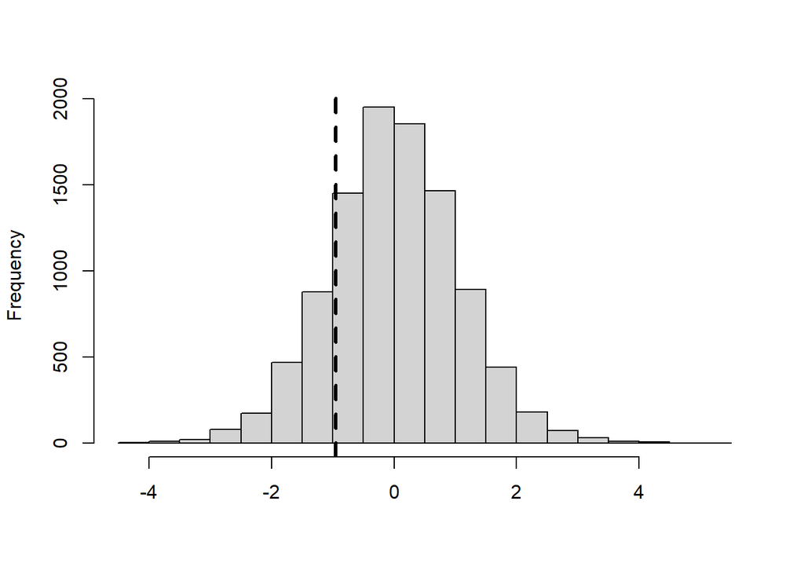

```r
set.seed(123)

#Using code from class
Nbytwo <- function(y,w) {
  N = length(y)
  Ypot = matrix(numeric(N*2), ncol=2)
  for (i in 1:N) {
    if (w[i]==1) {
      Ypot[i,1] = NA
      Ypot[i,2] = y[i]
    }
    else {
      Ypot[i,1] = y[i]
      Ypot[i,2] = NA
    }
  }
  return(Ypot)
}

TUNEQUALCOMPUTE = function(y,w, taustar=0) {
  # Computes t statistic with unequal variances
  N = length(y)
  N1 = sum(w)
  N0 = N - N1
  tauhat = mean(y[w==1]) - mean(y[w==0])
  s0sq = var(y[w==0])
  s1sq = var(y[w==1])
  Tobs = (tauhat - taustar) / sqrt(s0sq/N0+s1sq/N1)
  return(Tobs)
}

imputeundersharpnull = function(Y,taustar=0){
  N = dim(Y)[1]
  for (i in 1:N) {
    if (is.na(Y[i,1])) Y[i,1] = Y[i,2]-taustar
    else Y[i,2] = Y[i,1]+taustar
  }
  return(Y)
}

FISHER_TEST = function(y,w, taustar, ITER, show_hist=TRUE) {
  # Tests sharp null H0:tau_i=taustar against tau_i>taustar
  N = length(y) # Number of units
  Ypot = Nbytwo(y,w)
  Tobs = TUNEQUALCOMPUTE(y,w, taustar) # Calculate observed value of statistic
  Yimp = imputeundersharpnull(Ypot, taustar) # Create imputed matrix of potential outcomes
  Tarray = NULL
  for (i in 1:ITER) {
    wnew = sample(w) # this command randomly permutes the sequence x
    ynew = numeric(N)
    for (i in 1:N) ynew[i]=Yimp[i,wnew[i]+1]
    Tnew =TUNEQUALCOMPUTE(ynew,wnew, taustar)
    Tarray = c(Tarray, Tnew)
  }
  if (show_hist==TRUE) {
    hist(Tarray, main=NULL, xlab=NULL)
    abline(v=Tobs, lty=2, lwd=3.0)
  }
  # Calculate p-value for greater than alternative
  pval_plus = sum(Tarray >= Tobs)/ITER
  # Calculate p-value for smaller than alternative
  pval_minus = sum(Tarray <= Tobs)/ITER
  # Calculate p-value for two-sided alternative
  pval_twosided = sum(abs(Tarray) >= abs(Tobs))/ITER
  return(c(pval_plus, pval_minus, pval_twosided))
}

w_p3 = c(rep(1, 10), rep(0, 11))
FISHER_TEST(table_4$BP.after, w_p3, 0, 10000)
```

[1] 0.8247 0.1754 0.3492

Given our large p-value, we fail to reject the null hypothesis.  
The smallest possible p-value would 1/10000, or 0.0001.

### d)

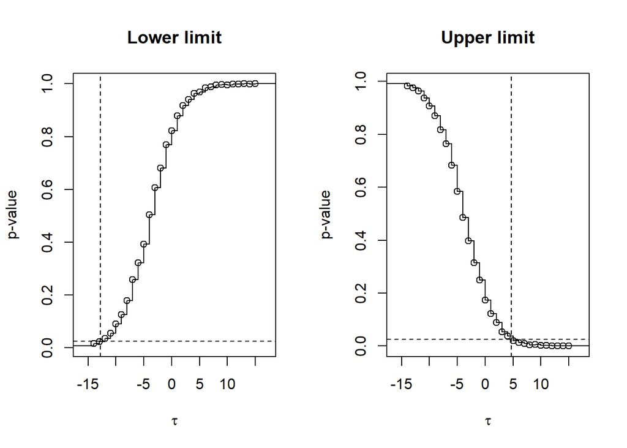

```r
INTERVALFISHER = function(y,w,ITER,theta_min, theta_max, m, alpha) {
  int = (theta_max - theta_min)/(m-1)
  taustarvec = seq(theta_min,theta_max,int)
  pvalarray_g = numeric(m)
  pvalarray_s = numeric(m)
  for (i in 1:m) {
    pvalarray_g[i] = FISHER_TEST(y, w, taustarvec[i],ITER, FALSE)[1]
    pvalarray_s[i] = FISHER_TEST(y, w, taustarvec[i],ITER, FALSE)[2]
  }
  # Calculating lower limit
  if (sum(pvalarray_g == alpha/2) == 1) tau_l = taustarvec[pvalarray_g==alpha/2]
  else {
    plbelow=max(pvalarray_g[pvalarray_g<alpha/2])
    plabove=min(pvalarray_g[pvalarray_g>alpha/2])
    tau_l_below = taustarvec[pvalarray_g==plbelow]
    tau_l_above = taustarvec[pvalarray_g==plabove]
    tau_l = tau_l_below + (tau_l_above - tau_l_below)* (alpha/2 - plbelow)/(plabove-plbelow)
  }
  # Calculating upper limit
  if (sum(pvalarray_s == alpha/2) == 1) tau_u = taustarvec[pvalarray_s==alpha/2]
  else {
    pubelow=max(pvalarray_s[pvalarray_s<alpha/2])
    puabove=min(pvalarray_s[pvalarray_s>alpha/2])
    tau_u_below = taustarvec[pvalarray_s==pubelow]
    tau_u_above = taustarvec[pvalarray_s==puabove]
    tau_u = tau_u_below + (tau_u_above - tau_u_below)* (alpha/2 - pubelow)/(puabove-pubelow)
  }
  pminus=stepfun(taustarvec[-1],pvalarray_s)
  pplus =stepfun(taustarvec[-1],pvalarray_g)
  par(mfrow=c(1,2))
  plot(pplus, main="Lower limit", xlab=expression(tau), ylab="p-value")
  abline(v=tau_l, lty=2)
  abline(h=alpha/2, lty=2)
  plot(pminus, main="Upper limit", xlab=expression(tau), ylab="p-value")
  abline(v=tau_u, lty=2)
  abline(h=alpha/2, lty=2)
  return(c(tau_l, tau_u))
}

i_conf_int = INTERVALFISHER(table_4$BP.after, w_p3, 5000, -15, 15, 31, .05)
```

```r
cat("The confidence interval for estimand (i) is (", i_conf_int[1], ",", i_conf_int[2], ").", sep='')
```

```
## The confidence interval for estimand (i) is (-12.83051,4.712644).
```

```r
ii_conf_int = INTERVALFISHER(table_4$Observed.reduction, w_p3, 5000, -15, 15, 31, .05)
```

[figure not shown]

```r
cat("The confidence interval for estimand (ii) is (", ii_conf_int[1], ",", ii_conf_int[2], ").", sep='')
```

```
## The confidence interval for estimand (ii) is (-12.51786,1.155172).
```